# Neural Networks Part 1

Table of Contents

What are neural networks? Modern applications of neural networks Common components and notation of a neural network The input layer The hidden layer(s) Step 1: Constructing new features using forward propagation Computing linear combinations of features Analogy to linear regression Impact of weights on the new feature Z generated by the neural network Impact of biases on the new feature Z generated by the neural network How do we initialize the weights and biases in practice? Non-linear transformations using an activation function The sigmoid activation function Rectified linear units (ReLUs) Leaky rectified linear units (Leaky ReLUs) A full round of forward propagation Step 2: Evaluating the model fit using the cost function Cross-Entropy cost function Step 3: Optimizing neural network parameters using backward propagation Finding the gradients dW and db using back propagation Intuition for back propagation Derivative terms for back propagation in a shallow neural network A full round of back propagation First let's back propagate from the output layer to the hidden layer Next let's back propagate from the hidden layer to the input layer Optimizing parameters W and b using gradient descent Summary Additional reading and references

## What are neural networks?

Neural networks are a set of algorithms that are inspired by neural circuits in the brain. These algorithms can be computationally intensive, and have recently exploded in popularity due to advances in computing technology.

Neural networks work by taking linear combinations of predictors to construct new representations of our features. Non-linear functions are applied to the new features to model the potential non-linearity in the dataset. This family of learning methods can be used for classification and regression problems.

### Modern applications of neural networks

Neural networks have been applied to several real-world problems, from [determining medical diagnoses by classifying images](https://towardsdatascience.com/medical-diagnosis-with-a-convolutional-neural-network-ab0b6b455a20) to [training a self driving car](https://towardsdatascience.com/deep-learning-for-self-driving-cars-7f198ef4cfa2) to [biomedical text mining for extracting relevant patient information](https://medium.com/@Petuum/applying-neural-networks-to-biomedical-text-mining-fe655270c12). The main advantages of neural networks are the following:

- They can detect nonlinear relationships and interactions between predictor variables
- The mathematics underpinning neural networks relies less on statistical assuptions we usually impose in other models
- Neural networks are modular, and many architectures are available to model different problems

### Common components and notation of a neural network

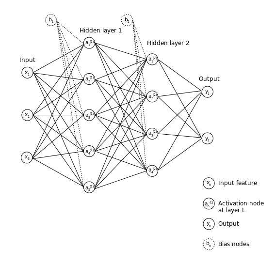

There are [several flavors of neural network architectures](https://medium.com/cracking-the-data-science-interview/a-gentle-introduction-to-neural-networks-for-machine-learning-d5f3f8987786), each one having their own advantages and disadvantages for solving different problems. The diagram above illustrates a feed-forward neural network, where information flows forward from the input to the output, and no information feeds back into the network.

#### The hidden layer(s)

The hidden layer is where the new values are stored from taking linear combinations of features from the input layer and applying non-linear transformations. These nodes are are known as activation nodes, and they represent a single new feature.

A neural network with a single hidden layer is known as a shallow neural network. However, we can add more complexity in the model by adding more hidden layers. Neural networks with more than 1 hidden layer are known as deep neural networks (DNNs), and the application of DNNs is known as deep learning.

To illustrate the main concepts underpinning neural networks for the next two lectures, we'll code up a shallow feedforward neural network from scratch. There are three main phases in a feedforward neural network that we'll go over for the remaining lecture:

1. Constructing new features in forward propagation
2. Evaluating the performance of forward prop using a cost function
3. Tuning / correcting model parameters using backward propagation

## Step 1: Constructing new features using forward propagation

The training phase of a neural network is called [forward propagation](https://towardsdatascience.com/forward-propagation-in-neural-networks-simplified-math-and-code-version-bbcfef6f9250). It consists of iteratively computing linear combinations of the input fed into each layer, followed by a non-linear transformation of the combined features. This is repeated for each hidden layer until we reach the output layer.

### Computing linear combinations of features

#### Analogy to linear regression

While this problem is slightly different from a linear regression problem in that we are solving for the output Z rather than using X and Z to estimate our coefficients, we actually have the same objective, and we're trying to estimate two parameters:

1. The weights (w), which is equivalent to the regression coefficients β
2. The bias (b) values, which is equivalent to the intercept .

#### Impact of weights on the new feature Z generated by the neural network

For now, let's see how the two parameters w and b affect the solution Z, and then plot the relationship between X and Z. We'll take the linear combinations with 1 to 3 weights and biases of different values.

The plot is generated by a custom accessory function plotLSLines located in the lesson directory.

[figure not shown]

ans =

Figure (1) with properties: Number: 1 Name: '' Color: [0.9400 0.9400 0.9400] Position: [680 678 560 420] Units: 'pixels' Show all properties

```matlab
% !!! IMPORTANT: ADD ALL FUNCTIONS TO MATLAB PATH !!!
addpath(genpath('.'))

% Initialize inputs using random numbers using a fixed random number generator (rng)
% for reproducibility
rng(2);
X = normrnd(0, 1, [3, 20]);

% Example with three different weight vectors
wArray = [[1; 0;  0], ...   % One weight
          [1; 5;  0], ...   % Two weights
          [1; 2; -5]];      % Three weights
b = randn([1, 20]) * 0.01;

% Construct several values for Z by changing the weight
% parameters and plotting the least-square lines.
for i = 1:size(wArray, 2)
    Z1{i} = X' * wArray(:, i) + b';
end
plotLSLines(X', Z1, 'weights')
```

As you can see, different combinations of weights influence Z, and show that this is a really important parameter to tune in the model.

#### Impact of biases on the new feature Z generated by the neural network

Now that we saw how the weights scale our features linearly, let's see how the biases influence the output Z.

```matlab
w = [1; 2; -5];                     % Three activation nodes with fixed values
bArray = [zeros([1, 20]); ...        % All zeros
          randn([1, 20]) * 0.01; ... % Small random values
          ones( [1, 20])];           % All tens

for i = 1:size(wArray, 2)
    Z2{i} = X' * w + bArray(i, :)';
end
plotLSLines(X', Z2, 'biases')
```

[output not shown]

The bias parameter at first glance seems to have very little impact on the model's output. However, let's see what happens when we apply a non-linear transformation to the dataset.

#### How do we initialize the weights and biases in practice?

Without knowing the true relationship between the predictor and response variables, we need to initialize the weight and bias parameters somehow. It turns out that [intializing neural networks with small and random values for w and b is a better way](https://machinelearningmastery.com/why-initialize-a-neural-network-with-random-weights/) to train these parameters than setting them to all zero or one.

We'll discuss why we need to initialize neural networks with small and random values for these parameters in the next lecture.

### Non-linear transformations using an activation function

In this section, we'll discuss different ways to add non-linearity into the computed variable Z, and the pros / cons of each method.

#### The sigmoid activation function

One way to transform the data is to use the sigmoid activation function (aka logit transformation) to transform our data into probabilities with values ranging from [0, 1]. The formulation of the sigmoid activation function and the ideal distribution is shown below:

```matlab
plotSigmoidFunction()
```

[output not shown]

The plot is generated by a custom accessory function plotSigmoidFunction located in the lesson directory.

To access all the activation functions described in this lecture, we can use the activationFnc script provided in the project folder (documentation described below) to transform our values.

function A = activationFnc(Z, fnc, epsilon)

% INPUTS:

% Z: An array of the dataset we're intending to transform.

% fnc: A string denoting the specific activation function we're using.

% There are 3 arguments you can input:

% 'Sigmoid'

% 'ReLU'

% 'Leaky ReLU'

% epsilon (optional): A floating value corresponding to the scaling parameter

% used for the 'Leaky ReLU' activation fucntion.

% The default value for epsilon is 0.01.

% OUTPUT:

% A: An array of the transformed dataset.

end

Applying the sigmoid activation function to Z values obtained from changing w

```matlab
% Compute y using the Z1 cell array containing the results from using different w values
for i = 1:size(Z1, 2)
    y1{i, :} = activationFnc(Z1{i}', 'Sigmoid');
end
plotSigmoidFunction(X', y1, 'weights')
```

[output not shown]

As we add additional weight parameters, the transformed values tend to converge to a value of 0 and 1. This feature of the sigmoid activation function is especially useful for binary classification, where we need to draw out a decision boundary between two classes.

Applying the sigmoid activation function to Z values obtained from changing b

```matlab
% Compute y using the Z2 cell array containing the results from using different b values
for i = 1:size(Z2, 2)
    y2{i} = activationFnc(Z2{i}', 'Sigmoid');
end
plotSigmoidFunction(X', y2, 'biases')
```

[output not shown]

Using a bias value of either 0 or small random initializations results in faster convergence of transformed datapoints to either 0 or 1, compared to setting b = 1. However, setting b = 0 and b = random does produce slightly different results. It turns out that after several iterations of forward propagation, the bias will help these values converge faster than setting b = 0.

### Rectified linear units (ReLUs)

While the Sigmoid activation function is easy to interpret and is simple to apply, there are issues with using it as an activation function:

1. With each iteration, the term in the sigmoid function becomes infinitesimally small. When correcting our parameters in back propagation (covered in the next section), correcting these extremely small values result in slower updates. This is called the vanishing gradient problem, and is an issue when it comes to optimizing neural network parameters using gradient descent.
2. Further, our values are between 0 and 1. This is not really useful for regression problems.

This basically sets negative values to 0, while leaving the original transformed value intact. The ReLU activation function has the following non-linear distribution:

```matlab
plotReLU()
```

[output not shown]

The ReLU has gained popularity in recent years because it takes care of the problems faced by the Sigmoid activation function, such as:

1. The correction term in back propagation is not infinitesimally small. This rectifies the vanishing gradient problem.
2. Because only a few neurons would be activated (negative values are all 0), this makes the model more efficient.

### Leaky rectified linear units (Leaky ReLUs)

The ReLU does have its own set of problems, such as handling real negative values (since they're set to 0, the model will essentially ignore these values).

There is an improved method of the ReLU: the leaky ReLU! Instead of setting to value to 0 for negative numbers, we'll scale the negative values using a small weight (usually this weight, which we'll denote as epsilon (ε) is set to 0.01). This will cause a smaller gradient to flow for the negative values, and thus improves our performance with negative numbers.

The leaky ReLU has the following distribution:

```matlab
plotLeakyReLU()
```

[output not shown]

Now that we have covered a single round of combing features and adding non-linearity to the combined features, we have the tools to run a full round of forward propagation.

### A full round of forward propagation

Let's now put all of these concepts together to run forward propagation in a shallow neural network using a breast cancer datasets built into MATLAB.

The dataset can be called using the load cancer_dataset command, and a comprehensive description of the dataset can be found by typing in help cancer_dataset.

- The input is a matrix of 9 features from 699 biopsies. The features include attributes such as adhesion, cell size, and cell shape. These are stored in the cancerInputs variable.
- The cancerTargets variable is a 2 x 699 matrix, where the first column corresponds to benign, and the the second column corresponds to malignant. Thus, we will perform binary classification.

To save space in the code blocks in this lecture, we can use the accessory function loadCancerData to do the following steps:

1. Load the dataset and target variables
2. Split the dataset and target variables into training and test datasets
3. Standardize the input datasets to have a mean = 0 and standard deviation of 1.

We'll use only 2 activation nodes in the hidden layer. Our (naive) hypothesis is that two activation nodes are able to capture the differences in a 2-class (binary) classification problem. We'll discuss a systematic way to choose the number of hidden nodes needed to optimize the performance of the neural network in the next lecture.

The sigmoid activation function will be used to demonstrate the implementation of forward propagation. However, you can feel free to test out the other activation functions, and how they impact the output from the model.

```matlab
clear all;
rng(2);

% Load the cancer data
[Xtrain, Ytrain, Xtest, Ytest] = loadCancerData();

numberOfHiddenNodes = 2;
actFnc = 'Sigmoid';

% Intialize the weights and biases from input -> hidden layer
w1 = randn([size(Xtrain, 2), numberOfHiddenNodes]) * 0.01;
b1 = randn([size(Xtrain, 1), 1]) * 0.01;
```

Let's now run forward propagation, first from the input layer to the hidden layer:

```matlab
Z1 = Xtrain * w1 + b1;
A1 = activationFnc(Z1, actFnc);
```

Now we need to run forward propagation one more time, from the hidden layer to the output layer. We will use the values A1 as the input for this round. Additionally, we will not add additional biases in this layer. Finally, we'll use the same activation function.

```matlab
% Intialize the weights from input -> hidden layer
w2 = rand(size(A1, 2), 1) * 0.01;
b2 = 0;

Z2 = A1 * w2 + b2;
A2 = activationFnc(Z2, actFnc);
ypred = A2;
```

That's one full round of forward propagation! Now we need to now see how well our model performed using a cost function.

## Step 2: Evaluating the model fit using the cost function

Next, we need to evaluate how well our model has performed in it's initial pass through using a cost function. Because we are performing a binary classification problem, we can use the Cross-Entropy cost function.

### Cross-Entropy cost function

The cost value (J) can be computed using the costFunction function provided. The docstring is provided below:

function J = costFunction(Y, yhat, L)

% INPUTS

% Y: A vector containing the true values for Y.

% yhat: A vector containing the predicted values for Y from the

% model.

% L: A string corresponding to the loss function used. There are 4

% loss functions that can be called:

% 'L1': The L1 / least absolute errors loss function.

% 'L2': The least squares error loss function.

% 'Kullback-Leibler': The KL loss function.

% 'Log-loss': The cross entropy loss function.

% OUTPUT

% J: A floating point value corresponding to the loss value.

end

```matlab
J = costFunction(Ytrain, ypred, 'Log-Loss')
```

[output not shown]

Now that we have a cost value, we can start to optimize our neural network algorithm using backward propagation.

## Step 3: Optimizing neural network parameters using backward propagation

After computing the cost, we know how good or how bad our model performed overall. In neural networks, we need to tell the algorithm how to adjust the weight and bias parameters so that the cost goes down in the next iteration, until we reach a stable minimum cost value. This process is called back propagation, and the optimization algorithm we use to update the weights and the biases is gradient descent.

### Finding the gradients dW and db using back propagation

The objective of back propagation is to determine how much we should change w and b such that we minimize the cost. Thus, we need to find an expression that allows us to relate the cost back to the parameter. The gradient, or the values from solving partial differential equations of the cost with respect to W () and b () will tell us how much error a specific activation node contributes to the overall model error.

#### Intuition for back propagation

Let's consider the gradient (the same logic applies for ) and work backwards from the output layer to the input layer. There are three places where the model can go wrong:

As you can see, each layer is chained together. If there is an error in Z1, it will propagate all the way to the output layer. Fortunately, because we know how the network is connected, we can figure out partial differential terms that will connect the cost to any given weight or bias parameter that needs to be adjusted to lower the cost. We won't go over the derivation for each term (honestly, you can probably just Google them), but in practice, we would work these differential equations individually and use the chain rule to compute the gradients.

#### Derivative terms for back propagation in a shallow neural network

The following set of equations are used in our shallow neural network to compute the gradients for each parameter (denoted as dw2, dw1, and db1).

Output layer to hidden layer:

- (We did not introduce bias to the last layer)

Hidden layer to input layer:

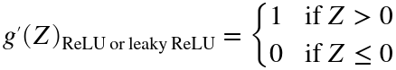

### A full round of back propagation

Now let's codify the expressions above to run a full round of back propagation. First we need to initialize constants that will be used in back propgation.

```matlab
m = size(Xtrain, 1);
```

#### First let's back propagate from the output layer to the hidden layer

```matlab
dZ2 = A2 - Ytrain;
dW2 = (1/m) .* (A1' * dZ2);
```

#### Next let's back propagate from the hidden layer to the input layer

```matlab
dZ1  = (w2 * dZ2') .* (1 - A1.^2)';
dW1  = (1/m) .* Xtrain' * dZ1';
db1  = (1/m) .* sum(dZ1', 2);
```

We have just completed the first iteration of back propagation, which relates the cost value J back to the parameters w1, w2, and b1. The last step we need to do is to update the weights and biases. We can do that using the gradient descent optimization algorithm.

### Optimizing parameters W and b using gradient descent

where α is the learning rate hyperparameter, a positive constant value that controls how fast we move along the gradient. Further, dW and db are the gradients we computed from back propagation.

We can perform gradient descent for w1, w2, and b1 using the code below:

```matlab
alpha = 0.05;
w2 = w2 - (alpha .* dW2);
w1 = w1 - (alpha .* dW1);
b1 = b1 - (alpha .* db1);
```

We have just completed a single round of training and optimizing a neural network. To train the neural network even more, we would iterate the entire process of forward propagation, computing the cost, and backward propagation several times until we reach the minimum cost value.

## Summary

We have covered how neural networks work under the hood, and coded a shallow neural network from scratch. In the next lecture, we'll combine what we've learned in this lecture and train a shallow neural network using the breast cancer dataset described in this lecture. We will also cover some of the issues commonly encountered in training a neural network as well as how to optimize the hyperparameters of a neural network. Finally, we'll benchmark the neural network against a logistic regression classifier.

## Additional reading and references

- A [generalized tutorial for learning about neural networks](https://medium.com/datathings/neural-networks-and-backpropagation-explained-in-a-simple-way-f540a3611f5e) that is language-agnostic.
- The [various flavors of neural networks](https://towardsdatascience.com/the-mostly-complete-chart-of-neural-networks-explained-3fb6f2367464), and how they are currently being used in real-world settings.
- Heuristics on deciding [how many hidden layers and activation nodes](https://machinelearningmastery.com/how-to-configure-the-number-of-layers-and-nodes-in-a-neural-network/) to initialize in a neural network.
- [Other activation functions, their usage, and generalizations about pros/cons](https://medium.com/@himanshuxd/activation-functions-sigmoid-relu-leaky-relu-and-softmax-basics-for-neural-networks-and-deep-8d9c70eed91e).